# lab01

Патракова Екатерина, РИ-440004

1 октября 2017 г

Задание 1 Сгенерируйте 200 случайных значений из стандартного экспоненциального распределения и сохраните в вектор exp.1. Найдите среднее и стандартное отклонение из данных этого вектора.

```r
exp.1<-rexp(n=200)
exp.1.mean<-mean(exp.1)
exp.1.sd<-sd(exp.1)
```

Повторите, использовав следующие значения параметра ??: 0.1, 0.5, 5, 10, и сохраните результаты в векторы: exp.0.1, exp.0.5, exp.5, exp.10.

```r
exp.0.1<-rexp(n=200, rate=0.1)
exp.0.1.mean = mean(exp.0.1)
exp.0.1.sd = sd(exp.0.1)

exp.0.5<-rexp(n=200, rate=0.5)
exp.0.5.mean = mean(exp.0.5)
exp.0.5.sd = sd(exp.0.5)

exp.5<-rexp(n=200, rate=5)
exp.5.mean = mean(exp.5)
exp.5.sd = sd(exp.5)

exp.10<-rexp(n=200, rate=10)
exp.10.mean = mean(exp.10)
exp.10.sd = sd(exp.10)
```

Используйте функцию hist() для построения гистограммы полученного ранее стандартного распределения.

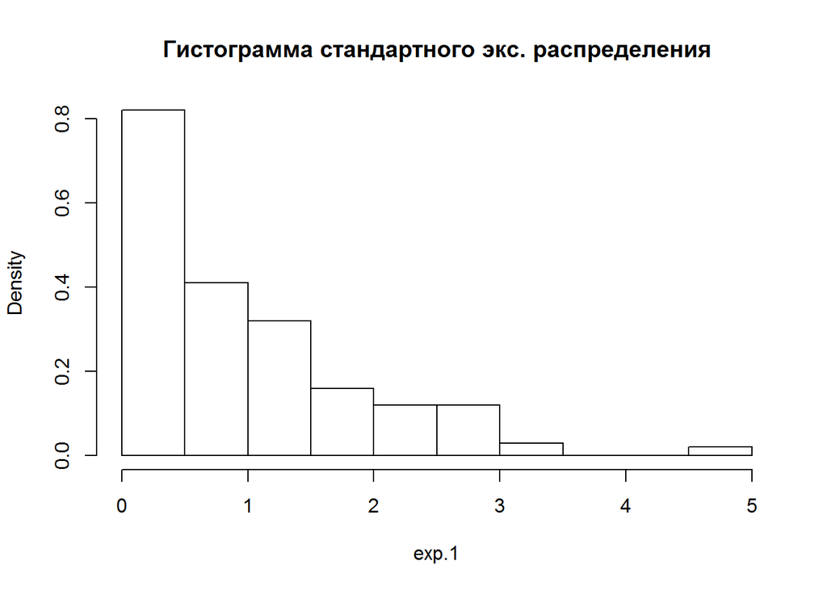

```r
hist(exp.1, main = "Гистограмма стандартного экс. распределения", prob = TRUE)
```

Полученная гистограмма близка к виду стандартного экспоненциального распределения. С увеличением количества наблюдений,распределение становится более точным.

Используйте функцию plot() с тем же самым вектором для построения графика значений в порядке следования.

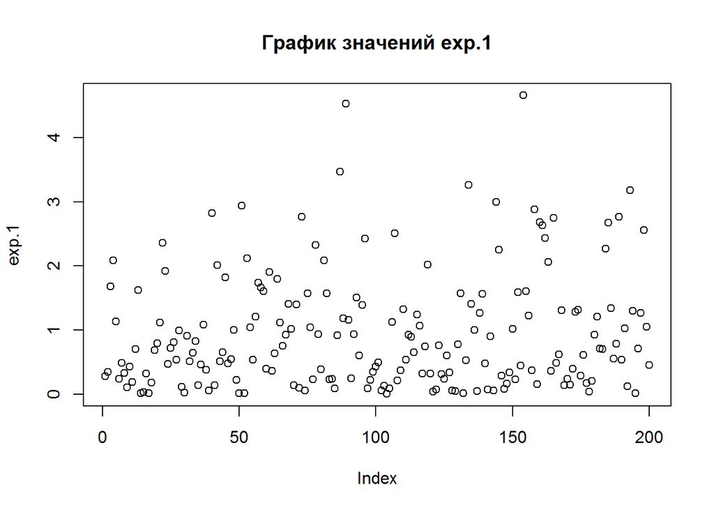

```r
plot(exp.1, main="График значений exp.1", prob = TRUE)
```

Используйте функцию plot() с любыми двумя полученными ранее векторами, чтобы получить диаграмму рассеяния (scatterplot) этих векторов относительно друг друга.

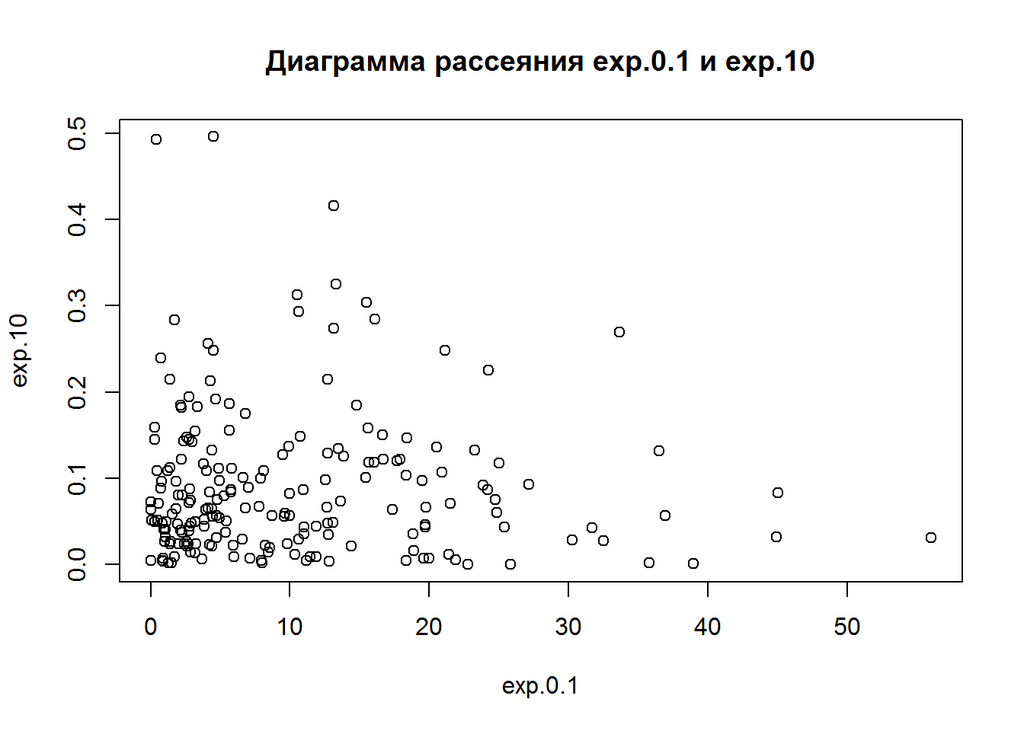

```r
plot(exp.0.1, exp.10, main="Диаграмма рассеяния exp.0.1 и exp.10", prob = TRUE)
```

Диаграмма рассеяния показывает, что между рассматриваемыми векторами нет линейной зависимости.

Теперь сравним свойства всех наших векторов. Для начала создадим вектор, содержащий средние значения каждого из 5 полученных ранее распределений в порядке их создания. Полученный вектор сохраним в переменную exp.means.

```r
exp.means <- c(exp.1.mean, exp.0.1.mean, exp.0.5.mean, exp.5.mean, exp.10.mean)
exp.sds <- c(exp.1.sd, exp.0.1.sd, exp.0.5.sd, exp.5.sd, exp.10.sd)
```

Далее необходимо создать следующие диаграммы рассеяния: Вектор с пятью средними относительно каждого из пяти векторов с различными значениями.

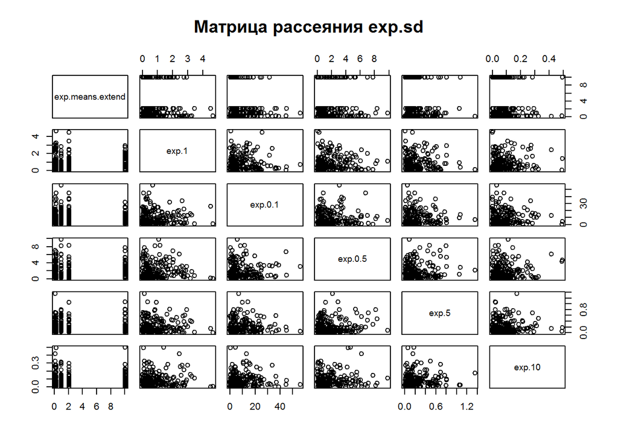

```r
#Для выравнивания размерностей векторов расширяем вектор exp.means

exp.means.extend <- rep(exp.means,each=40);
pairs(~exp.means.extend+exp.1+exp.0.1+exp.0.5+exp.5+exp.10, main="Матрица рассеяния exp.sd")
```

Диаграммы показывают, что между вектором средних и векторами распределений с различными ?? не наблюдается линейная связь.

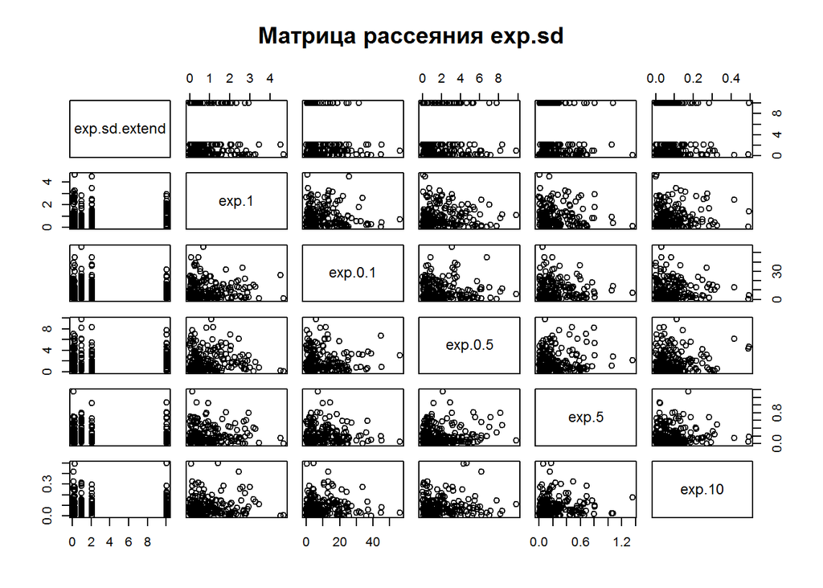

```r
exp.sd.extend <- rep(exp.means,each=40);
pairs(~exp.sd.extend+exp.1+exp.0.1+exp.0.5+exp.5+exp.10,main="Матрица рассеяния exp.sd")
```

Вектор с пятью средними относительно вектора с пятью стандартными отклонениями.

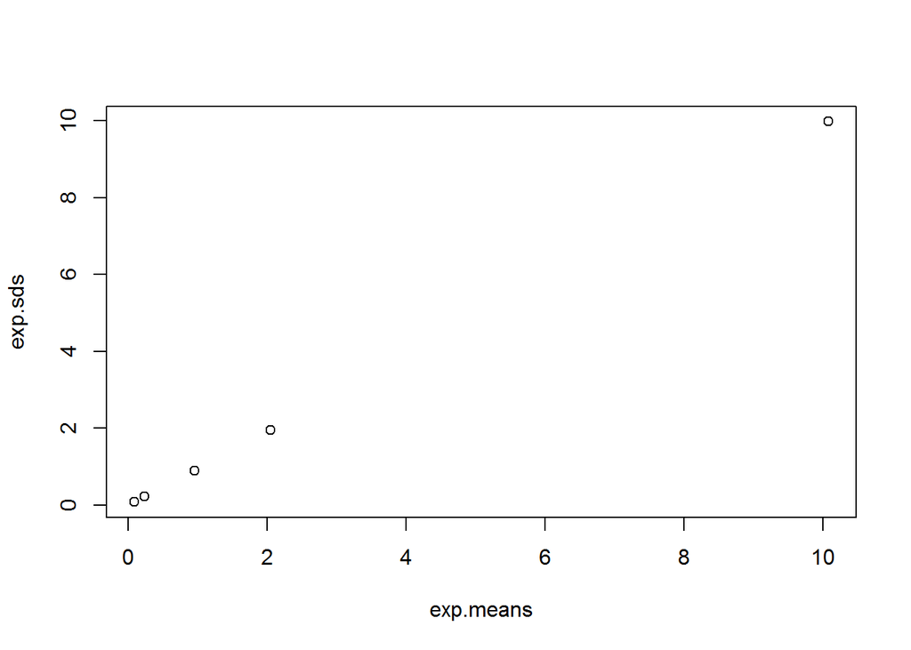

```r
plot(exp.means, exp.sds)
```

Между вектором средних и вектором стандратных отклонений наблюдается линейная зависимость.

Задание 2

Для демонстрации сгенерируйте 1100000 (1 млн. 100 тысяч) чисел из стандартного экспоненциального распределения и сохраните их в вектор huge.exp.1. Получите среднее и стандартное отклонение.

```r
huge.exp.1<-rexp(n=1100000)
huge.exp.1.mean<-mean(huge.exp.1)
huge.exp.1.sd<-sd(huge.exp.1)
```

Получите гистограмму huge.exp.1. Она соответствует функции 1 - e:^(-x)? Должна ли?

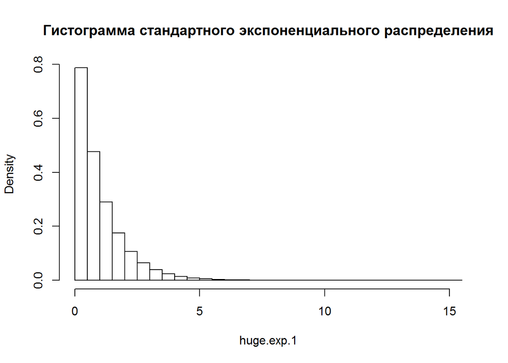

```r
hist(huge.exp.1, main = "Гистограмма стандартного экспоненциального распределения", prob = TRUE)
```

Получите среднее всех чисел из huge.exp.1 строго больших 1. Для проверки выборки может потребоваться новый вектор.

```r
huge.exp.more1<-huge.exp.1[huge.exp.1>1]
huge.exp.mean.more1<-mean(huge.exp.more1)
```

Получите матрицу huge.exp.1.mat, содержащую 1100 строк и 1000 колонок. Постройте гистограмму, использовав полученную матрицу. Что можно сказать о полученных данных?

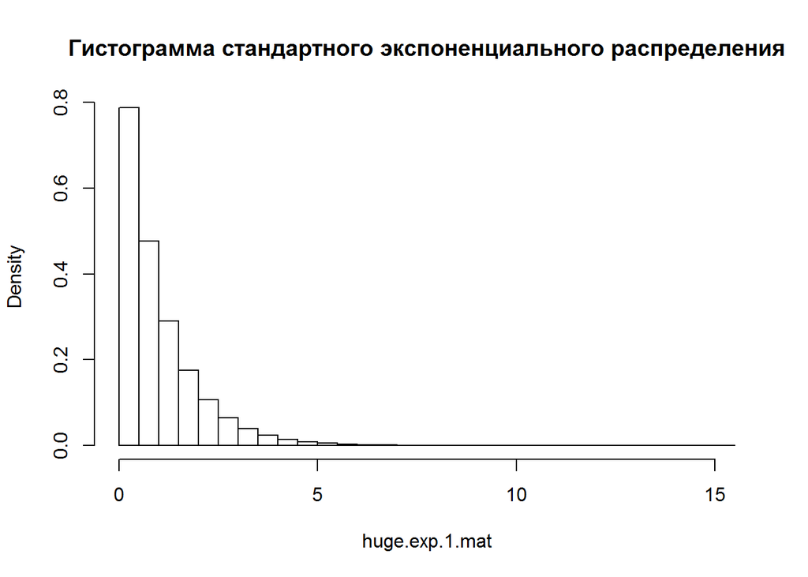

```r
huge.exp.1.mat<- matrix( huge.exp.1,nrow=1100)
hist(huge.exp.1.mat, prob = TRUE, main = "Гистограмма стандартного экспоненциального распределения")
```

Полученная гистограмма более близка к виду стандартного экспоненциального распределения, чем гистограмма для 200 значений. С увеличением количества наблюдений,распределение становится более точным.

Рассчитайте среднее 137-й колонки из huge.exp.1.mat.

```r
mean.137<-mean(huge.exp.1.mat[, 137])
```

Найдите среднее всей 1000 колонок и сохраните их в вектор. Отобразите диаграмму средних зннчений колонок. Объясните почему форма диаграммы отличается от виденных ранее.

Среднее значение экспоненциального распределения равно 1/lambda,в данном случае lambda=1, следовательно среднее значение каждой колонки стремится к 1.

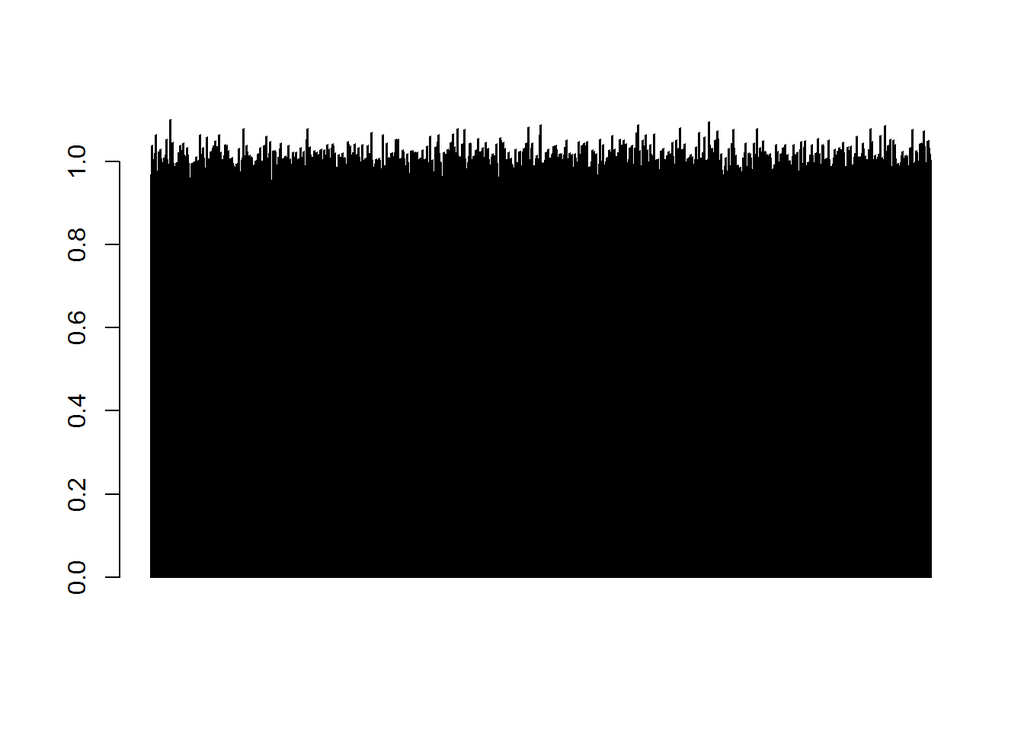

```r
matrix.means<-colMeans(huge.exp.1.mat)
barplot(matrix.means)
```

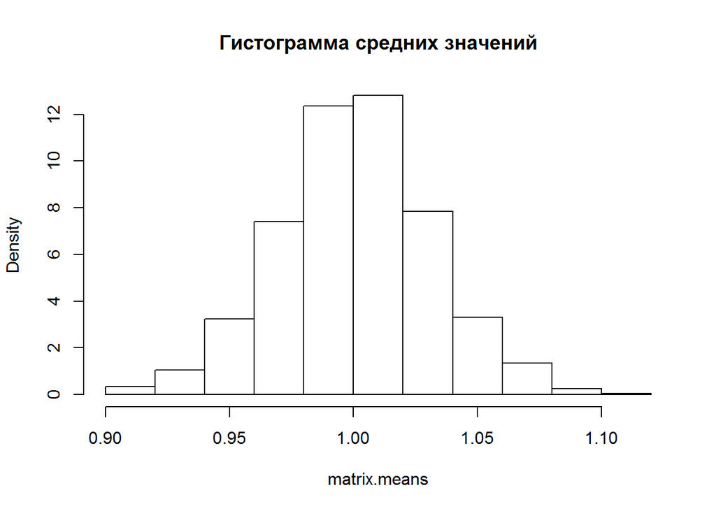

```r
hist(matrix.means, prob = TRUE, main = "Гистограмма средних значений")
```

Полученная гистограмма близка к нормальному распределению, что объясняется при помощи Центральной предельной теоремы. ЦПТ утверждает, что сумма большого количества независимых случайных величин имеет распределение, близкое к нормальному. Так как при нахождении среднего значения по колонкам применяется суммирование всех элементов этих колонок, полученные средние значения удовлетворяют данной теореме и образуют вектор нормально распределенных случайных величин.

```r
huge.exp.1.sqrt<-sqrt(huge.exp.1)
huge.exp.sqrt.mean<-mean(huge.exp.1.sqrt)
huge.exp.sqrt.sd<-sd(huge.exp.1.sqrt)
```